# Week4_Office_Hour

```python
# The office hour will start in 5 minutes.

# During the office hour, you can clarify and ask questions about course content.
# You can also talk about problems regarding your reading, code, etc.
# I am glad to explain and help. Let us begin soon!
```

Bullet points:

- To be able to run the code, it's recommended to put this demo into /resources directory.
- Often use dir() and help() function to understand the methods and functions

```python
# Import pandas and datetime

import pandas as pd
from datetime import datetime
```

```python
# Convert objects or string to datetime
pd.to_datetime('2020-09-21 2:10pm')
```

```
Timestamp('2020-09-21 14:10:00')
```

```python
# In pandas, a single point in time is represented as a Timestamp.
pd.to_datetime('09/21/2020')
```

```
Timestamp('2020-09-21 00:00:00')
```

```python
pd.to_datetime('09/01/2020', dayfirst = True)
```

```
Timestamp('2020-01-09 00:00:00')
```

```python
type(pd.to_datetime('09/21/2020'))
```

```
pandas._libs.tslibs.timestamps.Timestamp
```

```python
# If we supply a list or array of strings as input to to_datetime(),
# it returns a sequence of date/time values in a DatetimeIndex object,
# which is the core data structure that powers much of pandas time series functionality.

pd.to_datetime(['2018-05-05', '7/1/1997', 'Mar 31, 1995'])
```

```
DatetimeIndex(['2018-05-05', '1997-07-01', '1995-03-31'], dtype='datetime64[ns]', freq=None)
```

```python
type(pd.to_datetime(['2018-05-05', '7/1/1997', 'Mar 31, 1995']))
```

```
pandas.core.indexes.datetimes.DatetimeIndex
```

```python
# The data type datetime64[ns] indicates that the underlying data is stored as 64-bit
# integers, in units of nanoseconds (ns).

# This data structure allows pandas to
# compactly store large sequences of date/time values and efficiently perform
# vectorized operations using NumPy datetime64 arrays
```

```python
# If we’re dealing with a sequence of strings all in the same date/time format,
# we can explicitly specify it with the format parameter.

# We use the format codes %m (numeric month), %d (day of month), and
# %y (2-digit year) to specify the format.

pd.to_datetime(['12/25/19', '8/23/17', '12/15/12'], format = '%m/%d/%y')
```

```
DatetimeIndex(['2019-12-25', '2017-08-23', '2012-12-15'], dtype='datetime64[ns]', freq=None)
```

## Open Power Systems Data

The data set includes country-wide totals of electricity consumption, wind power production, and solar power production for 2006-2017.

The 5 columns:

- Date — The date (yyyy-mm-dd format)
- Consumption — Electricity consumption in GWh
- Wind — Wind power production in GWh
- Solar — Solar power production in GWh
- Wind+Solar — Sum of wind and solar power production in GWh

```python
# Let's import the data
# We choose the first column as index
# And parse the first column as datetime when reading the file
# This is an alternative to writing df['date'] = pd.to_datetime(df['date'], format='%d%b%Y')
opsd_daily = pd.read_csv('opsd_germany_daily.csv', index_col = 0, parse_dates = True)
opsd_daily.shape
```

```
(4383, 4)
```

```python
opsd_daily.loc['2014'].head(3)
```

[output not shown]

```python
# Add columns with year, month, and weekday name
opsd_daily['Year'] = opsd_daily.index.year
opsd_daily['Month'] = opsd_daily.index.month
opsd_daily['Weekday Name'] = opsd_daily.index.weekday
```

```python
opsd_daily.loc['2017-08-10']
```

```
Consumption     1351.491
Wind             100.274
Solar             71.160
Wind+Solar       171.434
Year            2017.000
Month              8.000
Weekday Name       3.000
Name: 2017-08-10 00:00:00, dtype: float64
```

```python
# We can subset by .loc()
# Using loc function to slice a group of rows and columns for datetime is Right inclusive
#opsd_daily.loc['2014-01-01': '2014-02-02']
opsd_daily.loc['2014-01-01': '2014-02-02': 2]
```

| Date | Consumption | Wind | Solar | Wind+Solar | Year | Month | Weekday Name |
| --- | --- | --- | --- | --- | --- | --- | --- |
| 2014-01-01 | 1080.080 | 220.085 | 30.493 | 250.578 | 2014 | 1 | 2 |
| 2014-01-03 | 1379.776 | 340.639 | 23.510 | 364.149 | 2014 | 1 | 4 |
| 2014-01-05 | 1182.416 | 175.812 | 18.067 | 193.879 | 2014 | 1 | 6 |
| 2014-01-07 | 1529.250 | 363.756 | 44.463 | 408.219 | 2014 | 1 | 1 |
| 2014-01-09 | 1572.194 | 430.360 | 23.977 | 454.337 | 2014 | 1 | 3 |
| 2014-01-11 | 1350.439 | 308.404 | 23.923 | 332.327 | 2014 | 1 | 5 |
| 2014-01-13 | 1582.797 | 124.885 | 21.976 | 146.861 | 2014 | 1 | 0 |
| 2014-01-15 | 1592.384 | 85.850 | 30.897 | 116.747 | 2014 | 1 | 2 |
| 2014-01-17 | 1571.637 | 121.368 | 20.624 | 141.992 | 2014 | 1 | 4 |
| 2014-01-19 | 1255.814 | 301.247 | 20.363 | 321.610 | 2014 | 1 | 6 |
| 2014-01-21 | 1624.806 | 15.643 | 5.835 | 21.478 | 2014 | 1 | 1 |
| 2014-01-23 | 1631.373 | 125.177 | 13.661 | 138.838 | 2014 | 1 | 3 |
| 2014-01-25 | 1399.124 | 145.786 | 19.051 | 164.837 | 2014 | 1 | 5 |
| 2014-01-27 | 1612.213 | 182.071 | 23.639 | 205.710 | 2014 | 1 | 0 |
| 2014-01-29 | 1659.960 | 213.550 | 24.072 | 237.622 | 2014 | 1 | 2 |
| 2014-01-31 | 1605.265 | 112.603 | 45.499 | 158.102 | 2014 | 1 | 4 |
| 2014-02-02 | 1265.416 | 107.799 | 33.744 | 141.543 | 2014 | 2 | 6 |

```python
# Partial indexing
opsd_daily.loc['2014-05'].head(3)
```

| Date | Consumption | Wind | Solar | Wind+Solar | Year | Month | Weekday Name |
| --- | --- | --- | --- | --- | --- | --- | --- |
| 2014-05-01 | 1099.884 | 52.133 | 108.002 | 160.135 | 2014 | 5 | 3 |
| 2014-05-02 | 1308.181 | 119.131 | 80.413 | 199.544 | 2014 | 5 | 4 |
| 2014-05-03 | 1196.095 | 69.523 | 104.548 | 174.071 | 2014 | 5 | 5 |

```python
# With pandas and matplotlib, we can easily visualize our time series data.
# Let's import matplotlib

import matplotlib.pyplot as plt
```

```python
# We’ll use seaborn styling for our plots, and let’s adjust the default figure size
# to an appropriate shape for time series plots.

import seaborn as sns
sns.set(rc = {'figure.figsize': (10, 5)})
```

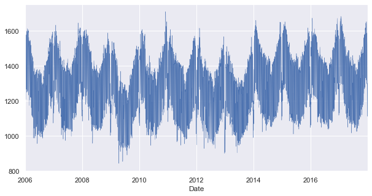

```python
# .plot() in DataFrame method
# Let's create a line of the 12-year analysis of Germany's daily electricity consumption
# Specify the linewidth, probably reduce the number
opsd_daily['Consumption'].plot(linewidth = 0.4)
```

- You can observe seasonality occurs at every year from 2006 to 2017. Seasonality is one of the most interesting characteristics in time series data.

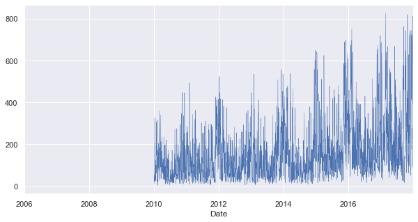

```python
# Let's plot the line for 12-year analysis of Germany's daily wind power production
opsd_daily['Wind'].plot(linewidth = 0.4)
```

- One remarkable observation from the graph is that Wind energy production data wasn't collected prior to 2010.

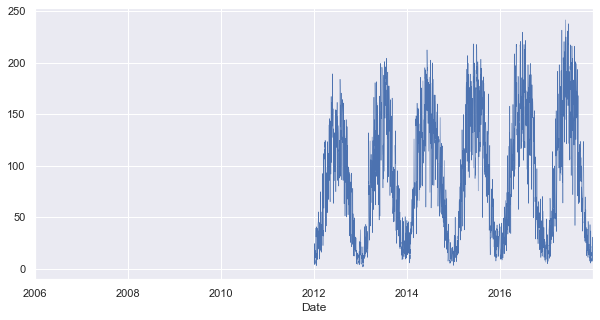

```python
# Solar — Solar power production in GWh
opsd_daily['Solar'].plot(linewidth = 0.5)
```

```python
# Recap: we can specify 2014-07 to view all July 2014 data entries
opsd_daily['2014-07']
```

| Date | Consumption | Wind | Solar | Wind+Solar | Year | Month | Weekday Name |
| --- | --- | --- | --- | --- | --- | --- | --- |
| 2014-07-01 | 1407.234 | 61.670 | 176.137 | 237.807 | 2014 | 7 | 1 |
| 2014-07-02 | 1418.936 | 61.838 | 145.466 | 207.304 | 2014 | 7 | 2 |
| 2014-07-03 | 1424.626 | 61.293 | 202.577 | 263.870 | 2014 | 7 | 3 |
| 2014-07-04 | 1401.193 | 65.633 | 185.181 | 250.814 | 2014 | 7 | 4 |
| 2014-07-05 | 1192.741 | 111.218 | 121.664 | 232.882 | 2014 | 7 | 5 |
| 2014-07-06 | 1096.519 | 101.609 | 180.376 | 281.985 | 2014 | 7 | 6 |
| 2014-07-07 | 1415.363 | 73.447 | 140.347 | 213.794 | 2014 | 7 | 0 |
| 2014-07-08 | 1455.751 | 111.337 | 59.153 | 170.490 | 2014 | 7 | 1 |
| 2014-07-09 | 1446.773 | 144.955 | 67.393 | 212.348 | 2014 | 7 | 2 |
| 2014-07-10 | 1430.759 | 95.164 | 100.137 | 195.301 | 2014 | 7 | 3 |
| 2014-07-11 | 1403.109 | 107.147 | 150.506 | 257.653 | 2014 | 7 | 4 |
| 2014-07-12 | 1176.602 | 45.451 | 133.663 | 179.114 | 2014 | 7 | 5 |
| 2014-07-13 | 1078.057 | 60.184 | 117.124 | 177.308 | 2014 | 7 | 6 |
| 2014-07-14 | 1386.762 | 123.226 | 135.799 | 259.025 | 2014 | 7 | 0 |
| 2014-07-15 | 1424.134 | 60.386 | 166.422 | 226.808 | 2014 | 7 | 1 |
| 2014-07-16 | 1436.438 | 12.139 | 170.333 | 182.472 | 2014 | 7 | 2 |
| 2014-07-17 | 1439.770 | 17.241 | 187.710 | 204.951 | 2014 | 7 | 3 |
| 2014-07-18 | 1419.386 | 37.017 | 199.131 | 236.148 | 2014 | 7 | 4 |
| 2014-07-19 | 1207.587 | 92.104 | 199.881 | 291.985 | 2014 | 7 | 5 |
| 2014-07-20 | 1113.844 | 94.327 | 137.696 | 232.023 | 2014 | 7 | 6 |
| 2014-07-21 | 1429.350 | 113.920 | 81.351 | 195.271 | 2014 | 7 | 0 |
| 2014-07-22 | 1440.878 | 140.531 | 129.393 | 269.924 | 2014 | 7 | 1 |
| 2014-07-23 | 1428.897 | 144.412 | 184.013 | 328.425 | 2014 | 7 | 2 |
| 2014-07-24 | 1425.512 | 98.949 | 158.319 | 257.268 | 2014 | 7 | 3 |
| 2014-07-25 | 1396.902 | 53.103 | 131.217 | 184.320 | 2014 | 7 | 4 |
| 2014-07-26 | 1184.844 | 20.656 | 137.144 | 157.800 | 2014 | 7 | 5 |
| 2014-07-27 | 1090.885 | 24.248 | 136.815 | 161.063 | 2014 | 7 | 6 |
| 2014-07-28 | 1399.811 | 38.484 | 145.287 | 183.771 | 2014 | 7 | 0 |
| 2014-07-29 | 1427.072 | 50.898 | 103.339 | 154.237 | 2014 | 7 | 1 |
| 2014-07-30 | 1421.525 | 75.132 | 81.030 | 156.162 | 2014 | 7 | 2 |
| 2014-07-31 | 1391.858 | 40.267 | 152.229 | 192.496 | 2014 | 7 | 3 |

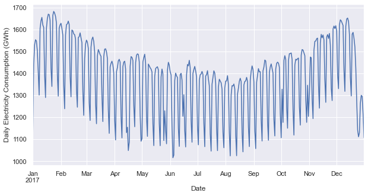

```python
# We can look at the seasonality by subsetting a year of data and plot
# By looking into the seasonality in a year, we can also try to observe if
# week seasonality/month seasonality exists in those columns

ax = opsd_daily.loc['2017', 'Consumption'].plot()
# We want the y-labels be (Daily Electricity Consumption (GWh))
ax.set_ylabel('Daily Electricity Consumption (GWh)')
```

### Interpretation

- We can clearly see the weekly oscillations
- Weekly oscillations are mostly consistent
- It's apparent at year level of granularity that drastic decrease in electricity consumption during Christmas and potentially the HAPPY NEW YEAR transpire. LED christmas lights are really efficient! (By Cliff)
- Stuff like factories stop operating?

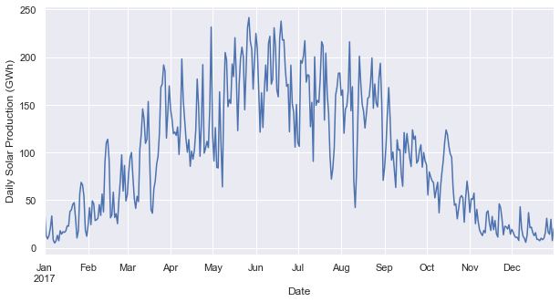

```python
ax = opsd_daily.loc['2017', 'Solar'].plot()
# We want the y-labels be (Daily Solar Production (GWh))
ax.set_ylabel('Daily Solar Production (GWh)')
```

### Interpretation

- During the summer months, the solar production tends to be higher compared to that in winter
- The monsoon seasons in Germany is a factor governing the spike/drop of solar energy production
- You can see some huge leaps between days in summer, which may represent how random climate factors have significantly influenced the solar energy production on specific (consecutive) days.

## Boxplot

A boxplot is a standardized way of displaying the distribution of data based on a five number summary (“minimum”, first quartile (Q1), median, third quartile (Q3), and “maximum”).

It can tell you about your outliers and what their values are. It can also tell you if your data is symmetrical, how tightly your data is grouped, and if and how your data is skewed.

Let's define the five number summary:

- first quartile (Q1/25th Percentile): the middle number between the smallest number (not the “minimum”) and the median of the dataset. It's shown as the lowest point of the box
- third quartile (Q3/75th Percentile): the middle value between the median and the highest value (not the “maximum”) of the dataset. It's shown as the highest point of the box
- interquartile range (IQR): the range between 25th to the 75th percentile.
- “maximum”: Q3 + 1.5*IQR (in seaborn, if the maximum value is within 1.5 times IQR, then will show the maximum value instead of Q3 + 1.5*IQR)
- “minimum”: Q1 -1.5*IQR (in seaborn, if the minimum value is within 1.5 times IQR, then will show the maximum value instead of Q1 - 1.5*IQR)

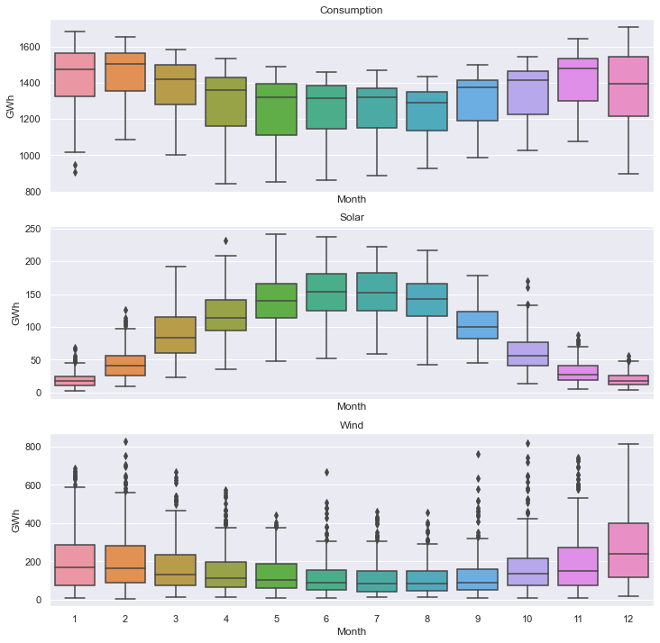

```python
# Next, let’s further explore the seasonality of our data with box plots, using seaborn’s boxplot() function

# group the data by different time periods and display the distributions for each group

# Specify the rows, columns in a subplot
# Specify figure size using a tuple
# Box in Boxplot represents 25% and 75%
# Observation which goes beyond or beneath the two lines are considered outliers


fig, axes = plt.subplots(3, 1, figsize = (12, 12), sharex = True)

for name, ax in zip(['Consumption', 'Solar', 'Wind'], axes):
    sns.boxplot(data = opsd_daily, x = 'Month', y = name, ax = ax)
    ax.set_ylabel('GWh')
    ax.set_title(name)
```

## How to interpret the boxplot??

- The median of electricity consumption shows a decreasing trend from approximately 1500 GWh per day January to roughly 1300 GWh per day during summer months (May - August). The figure rises gradually during September to November and bounces back the electricity consumption to approximately 1500 GWh per day. On December, the box range witnesses the broadest, indicating that the daily fluctuation of energy consumption is large.
- Overall, Solar production witnesses high median values (~150 GWh per day) between May and August, while wind energy production sees higher daily output between December and February. We can infer that in Germany, Solar energy production concentrates during the summer months (May - Auguest), while wind electricity production concentrates during winter.
- (Optional) There are extreme cases when unusually high output of solar energy (> Q3 + 1.5 * IQR) was recorded on January, February, April, October, November and December.
- (Optional) There are more often cases when unusually high output of winder energy (> Q3 + 1.5 * IQR) was recorded in Germany. In extremely windy days, the daily output of wind energy can be as high as more than 800 GWh.

```python
# Resample look at the highest, lowest, open, close
# Convenience method for frequency conversion and resampling of time series

# It's interesting to see that the difference between the highest and lowest day of
# wind energy production is enormous.
opsd_daily.loc['2017']['Wind'].resample('M').ohlc()
```

| Date | open | high | low | close |
| --- | --- | --- | --- | --- |
| 2017-01-31 | 307.125 | 686.578 | 31.375 | 124.784 |
| 2017-02-28 | 221.296 | 826.278 | 98.879 | 602.224 |
| 2017-03-31 | 463.541 | 666.659 | 71.216 | 260.808 |
| 2017-04-30 | 82.512 | 561.129 | 40.669 | 435.487 |
| 2017-05-31 | 440.713 | 440.713 | 55.642 | 304.100 |
| 2017-06-30 | 88.558 | 669.219 | 31.187 | 379.310 |
| 2017-07-31 | 326.425 | 353.673 | 33.863 | 125.196 |
| 2017-08-31 | 100.080 | 455.379 | 45.224 | 208.497 |
| 2017-09-30 | 34.233 | 761.751 | 16.478 | 198.308 |
| 2017-10-31 | 218.240 | 819.818 | 64.256 | 256.960 |
| 2017-11-30 | 420.446 | 743.280 | 62.667 | 66.389 |
| 2017-12-31 | 52.323 | 812.422 | 52.323 | 721.176 |

### Rolling windows

Rolling window operations are another important transformation for time series data. Similar to downsampling, rolling windows split the data into time windows and and the data in each window is aggregated with a function such as mean(), median(), sum(), etc.

Let’s use the rolling() method to compute the 7-day rolling mean of our daily data. We use the center=True argument to label each window at its midpoint

```python
# Compute the rolling mean for 7-days
# We want to see the change of 7-day average for energy consumption, wind production, and solar production
opsd_daily_7d = opsd_daily[['Consumption', 'Wind', 'Solar']].rolling(7, center = True).mean()
```

```python
# Let's take a look about the first 20 records of rolling mean
opsd_daily_7d.head(20)
```

[output not shown]

```python
# and the last 20 records of rolling mean
opsd_daily_7d.tail(20)
```

| Date | Consumption | Wind | Solar |
| --- | --- | --- | --- |
| 2017-12-12 | 1551.479561 | 557.838143 | 17.249714 |
| 2017-12-13 | 1546.841243 | 495.705857 | 17.758286 |
| 2017-12-14 | 1543.856889 | 442.531857 | 18.143714 |
| 2017-12-15 | 1538.790056 | 402.493857 | 19.604857 |
| 2017-12-16 | 1530.092747 | 332.350571 | 18.968143 |
| 2017-12-17 | 1516.918677 | 242.256286 | 14.956571 |
| 2017-12-18 | 1500.322721 | 184.056429 | 12.997000 |
| 2017-12-19 | 1478.366414 | 191.535714 | 11.341571 |
| 2017-12-20 | 1462.551239 | 258.776143 | 10.276714 |
| 2017-12-21 | 1440.342401 | 339.018429 | 9.895143 |
| 2017-12-22 | 1373.569914 | 403.728000 | 9.876286 |
| 2017-12-23 | 1308.374847 | 492.064429 | 13.037714 |
| 2017-12-24 | 1266.125593 | 535.439714 | 14.142143 |
| 2017-12-25 | 1234.624439 | 570.780429 | 15.120571 |
| 2017-12-26 | 1216.317254 | 621.566714 | 17.947571 |
| 2017-12-27 | 1208.214129 | 617.734286 | 17.807143 |
| 2017-12-28 | 1203.265211 | 604.699143 | 19.240143 |
| 2017-12-29 | NaN | NaN | NaN |
| 2017-12-30 | NaN | NaN | NaN |
| 2017-12-31 | NaN | NaN | NaN |

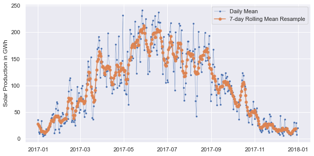

```python
# To better compare the rolling-mean with the daily energy consumption and production,
# one good idea is to intertwine the two trends into a visualization

# We want to compare the 2017 data
start, end = '2017-01', '2017-12'
# We can plot the weekly rolling mean for time series trend
fig, ax = plt.subplots()

# We plot the daily mean of solar production
# Particularly, we use dots as marker, with middle size 5, and thin linewidth 0.4
ax.plot(opsd_daily.loc[start:end, 'Solar'],
       marker = '.', markersize = 5, linewidth = 0.4, label = 'Daily Mean')
# Compare the rolling mean with the data
ax.plot(opsd_daily_7d.loc[start:end, 'Solar'],
       marker = 'o', markersize = 5, linestyle = '-', label = '7-day Rolling Mean Resample')
ax.set_ylabel('Solar Production in GWh')
ax.legend()
```

What difference between the two plots did you recognize?

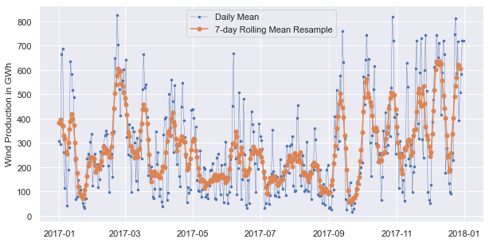

```python
# We can do similar comparisons for wind production

# We can plot the weekly rolling mean for time series trend
fig, ax = plt.subplots()

# We plot the daily mean of wind production
# Particularly, we use dots as marker, with middle size 5, and thin linewidth 0.4
ax.plot(opsd_daily.loc[start:end, 'Wind'],
       marker = '.', markersize = 5, linewidth = 0.4, label = 'Daily Mean')
# Compare the rolling mean with the data
ax.plot(opsd_daily_7d.loc[start:end, 'Wind'],
       marker = 'o', markersize = 5, linestyle = '-', label = '7-day Rolling Mean Resample')
ax.set_ylabel('Wind Production in GWh')
ax.legend()
```

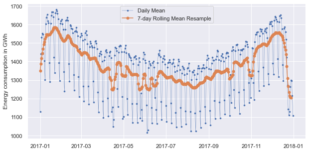

```python
# We can also get a closer understanding for energy consumption in Germany

# We can plot the weekly rolling mean for time series trend
fig, ax = plt.subplots()

# We plot the daily mean of energy consumption
# Particularly, we use dots as marker, with middle size 5, and thin linewidth 0.4
ax.plot(opsd_daily.loc[start:end, 'Consumption'],
       marker = '.', markersize = 5, linewidth = 0.4, label = 'Daily Mean')
# Compare the rolling mean with the data
ax.plot(opsd_daily_7d.loc[start:end, 'Consumption'],
       marker = 'o', markersize = 5, linestyle = '-', label = '7-day Rolling Mean Resample')
ax.set_ylabel('Energy consumption in GWh')
ax.legend()
```

# Correlation

The stats.pearsonr function takes two arrays as input and returns two float values, the **Pearson's correlation** and the **p-value**.

You can see in the documentation that correlation takes a value between -1 and +1, with 0 implying no correlation. We define

- Positive Correlation: The increase of column A is associated with the increase of column B
- Negative Correlation: The increase of column A is associated with the decrease of column B
- Strong Corrlation: The change of value in column A is approximately linear to the change of values of column B
- Exact linear relationship: When correlation equals 1 or -1, two columns form an exact linear relationship

```python
# We can use .corr() to obtain a matrix of variable-pair correlation
# By default, .corr() method uses pearson correlation
opsd_daily.corr()
```

|  | Consumption | Wind | Solar | Wind+Solar | Year | Month | Weekday Name |
| --- | --- | --- | --- | --- | --- | --- | --- |
| Consumption | 1.000000 | 0.133076 | -0.279543 | 0.027648 | 0.245311 | -0.095879 | -0.583504 |
| Wind | 0.133076 | 1.000000 | -0.308832 | 0.924745 | 0.347796 | 0.041196 | 0.022162 |
| Solar | -0.279543 | -0.308832 | 1.000000 | 0.076394 | 0.130046 | -0.083739 | -0.004921 |
| Wind+Solar | 0.027648 | 0.924745 | 0.076394 | 1.000000 | 0.416641 | 0.009679 | 0.021264 |
| Year | 0.245311 | 0.347796 | 0.130046 | 0.416641 | 1.000000 | -0.000881 | 0.003345 |
| Month | -0.095879 | 0.041196 | -0.083739 | 0.009679 | -0.000881 | 1.000000 | 0.001802 |
| Weekday Name | -0.583504 | 0.022162 | -0.004921 | 0.021264 | 0.003345 | 0.001802 | 1.000000 |

```python
opsd_daily.dropna(inplace = True)
```

```python
import scipy.stats as stats
corr, p_value = stats.pearsonr(opsd_daily.Consumption, opsd_daily.Wind)
print(corr, p_value)
```

```
0.1330759524174559 4.1682414913764916e-10
```

# Interpret p-values and correlation

- The underlying framework for p-value is hypothesis testing. We would validate or nullify a certain claim using hypothesis testing on data. The first thing we should know is null hypothesis. You can find very detailed tutorial about null hypothesis, so I just describe that in this problem, the null hypothesis is that

**Higher consumption of energy is not correlated with the higher production of wind**

- The alternative hypothesis states that Higher consumption of energy is correlated with the higher production of wind.
- p-value is the probability that we observed a correlation between consumption of energy and wind energy production to be as extreme as, or more extreme than the correlation we observed (0.1330759524174559) by chance.
- That probability is 4.1682414913764916e-10, which is very low. A nearly zero p-value means that it is highly unlikely to observe that by change, assuming that the null hypothesis is true.
- To test the hypothesis, we will choose a significance level (\alpha) as threshold, where commonly used alpha values are 0.05, 0.01. We say that we have sufficient evidence to reject the null hypothesis and in favor of the alternative hypothesis if the p-value is lower than the specified value (alpha).
- Since the p-value is less than the significance level, we conclude that:

**higher consumption of energy is a statistically significant factor associated with the higher production of wind energy**

```python
corr, p_value = stats.pearsonr(opsd_daily.Consumption, opsd_daily.Solar)
print(corr, p_value)
```

```
-0.27954273185828227 1.505758301064772e-40
```

## Weekly Trend Analysis

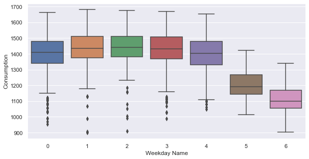

```python
sns.boxplot(data = opsd_daily, x = 'Weekday Name', y = 'Consumption')
```

```python
opsd_daily['Consumption'].resample('Y').ohlc()
```

| Date | open | high | low | close |
| --- | --- | --- | --- | --- |
| 2012-12-31 | 948.128 | 1615.078 | 899.827 | 969.81000 |
| 2013-12-31 | 906.910 | 1563.832 | 902.859 | 1068.42900 |
| 2014-12-31 | 1080.080 | 1659.960 | 1022.538 | 1183.51000 |
| 2015-12-31 | 1111.336 | 1651.314 | 1010.009 | 1158.10300 |
| 2016-12-31 | 1060.366 | 1672.320 | 1036.969 | 1212.56800 |
| 2017-12-31 | 1130.413 | 1682.002 | 1016.024 | 1107.11488 |

# Base Pay for Orchestra Employees

We are interested to know the correlation between the population in metropolitan area, and the base pay for the top orchestra players/musicians.

```python
orchestra_dict = {'Name': ['Los Angeles Philharmonic',
                          'Chicago Symphony Orchestra',
                          'San Francisco Symphony Orchestra',
                          'Boston Symphony Orchestra',
                          'New York Philharmonic',
                          'National Symphony Orchestra',
                          'Philadelphia Orchestra',
                          'Cleveland Orchestra',
                          'Pittsburgh Symphony Orchestra',
                          'Cincinnati Symphony Orchestra',
                          'Boston Pops Orchestra',
                          'Boston Modern Orchestra',
                          'Boston Civic Symphony'],


                 'Base_Pay_2015': [153400, 151320, 150454,
                             142896, 141113, 136136,
                             128700, 127504, 107117, 103500,
                                  74500, 78500, 90000]}
```

```python
# We create a dataframe from dictionary
orchestra = pd.DataFrame.from_dict(orchestra_dict)
orchestra
```

|  | Name | Base_Pay_2015 |
| --- | --- | --- |
| 0 | Los Angeles Philharmonic | 153400 |
| 1 | Chicago Symphony Orchestra | 151320 |
| 2 | San Francisco Symphony Orchestra | 150454 |
| 3 | Boston Symphony Orchestra | 142896 |
| 4 | New York Philharmonic | 141113 |
| 5 | National Symphony Orchestra | 136136 |
| 6 | Philadelphia Orchestra | 128700 |
| 7 | Cleveland Orchestra | 127504 |
| 8 | Pittsburgh Symphony Orchestra | 107117 |
| 9 | Cincinnati Symphony Orchestra | 103500 |
| 10 | Boston Pops Orchestra | 74500 |
| 11 | Boston Modern Orchestra | 78500 |
| 12 | Boston Civic Symphony | 90000 |

```python
cities = pd.read_html('wikipedia_data.html')[1]
cities=cities.iloc[:-1,[0,3,5,6,7,8]]
#cities
```

```python
orchestra_metro_dict = {'Los Angeles Philharmonic': 'Los Angeles',
                       'Chicago Symphony Orchestra': 'Chicago',
                       'San Francisco Symphony Orchestra': 'San Francisco Bay Area',
                       'Boston Symphony Orchestra': 'Boston',
                       'New York Philharmonic': 'New York City',
                       'National Symphony Orchestra': 'Washington, D.C.',
                       'Philadelphia Orchestra': 'Philadelphia',
                       'Cleveland Orchestra': 'Cleveland',
                       'Boston Pops Orchestra': 'Boston',
                        'Boston Modern Orchestra': 'Boston',
                        'Boston Civic Symphony': 'Boston',
                       'Pittsburgh Symphony Orchestra': 'Pittsburgh',
                       'Cincinnati Symphony Orchestra': 'Cincinnati'}
```

```python
# How to create a column called Metropolitan area based on the dictionary mapping?
# Original column is Name, the mapped column should be Metropolitan area

# Recap: map() Map values of Series according to input correspondence.
# Used for substituting each value in a Series with another value, from dict or from a Series
orchestra['Metropolitan area'] = orchestra['Name'].map(orchestra_metro_dict)
orchestra
```

|  | Name | Base_Pay_2015 | Metropolitan area |
| --- | --- | --- | --- |
| 0 | Los Angeles Philharmonic | 153400 | Los Angeles |
| 1 | Chicago Symphony Orchestra | 151320 | Chicago |
| 2 | San Francisco Symphony Orchestra | 150454 | San Francisco Bay Area |
| 3 | Boston Symphony Orchestra | 142896 | Boston |
| 4 | New York Philharmonic | 141113 | New York City |
| 5 | National Symphony Orchestra | 136136 | Washington, D.C. |
| 6 | Philadelphia Orchestra | 128700 | Philadelphia |
| 7 | Cleveland Orchestra | 127504 | Cleveland |
| 8 | Pittsburgh Symphony Orchestra | 107117 | Pittsburgh |
| 9 | Cincinnati Symphony Orchestra | 103500 | Cincinnati |
| 10 | Boston Pops Orchestra | 74500 | Boston |
| 11 | Boston Modern Orchestra | 78500 | Boston |
| 12 | Boston Civic Symphony | 90000 | Boston |

```python
# Aggregate the maximum salary pay (top orchestra in different metropolitan area)
orchestra.groupby('Metropolitan area').max()
```

| Metropolitan area | Name | Base_Pay_2015 |
| --- | --- | --- |
| Boston | Boston Symphony Orchestra | 142896 |
| Chicago | Chicago Symphony Orchestra | 151320 |
| Cincinnati | Cincinnati Symphony Orchestra | 103500 |
| Cleveland | Cleveland Orchestra | 127504 |
| Los Angeles | Los Angeles Philharmonic | 153400 |
| New York City | New York Philharmonic | 141113 |
| Philadelphia | Philadelphia Orchestra | 128700 |
| Pittsburgh | Pittsburgh Symphony Orchestra | 107117 |
| San Francisco Bay Area | San Francisco Symphony Orchestra | 150454 |
| Washington, D.C. | National Symphony Orchestra | 136136 |

```python
# rename column names
cities = cities.rename(columns = {'Population (2016 est.)[8]': 'Population_2016'})
```

```python
# Set the index as Metropolitan Area for both cities and orchestras
cities = cities.set_index('Metropolitan area')
orchestra = orchestra.set_index('Metropolitan area')
```

```python
# Do left join
cities_orchestra = pd.merge(orchestra, cities, how = 'left', left_index = True, right_index = True)
# Let's take a look about the merged data

# Many - to - many
# Many - to - one
# One - to - one
# One - to - many

# Subset only the Name, Base_pay for orchestra, and Population
cities_orchestra = cities_orchestra[['Name', 'Base_Pay_2015', 'Population_2016']]
# Convert object data type of population to int
cities_orchestra['Population_2016'] = cities_orchestra['Population_2016'].astype(int)
```

```python
cities_orchestra

# Correlation between base_pay and population
import scipy.stats as stats

corr, p_value = stats.pearsonr(cities_orchestra['Base_Pay_2015'], cities_orchestra['Population_2016'])
#cities_orchestra.dtypes
corr, p_value
```

[output not shown]

Takeaway 1:

- You can obtain a high correlation, but not a significant one (high p-value, which is greater than 0.05)
- You can obtain a low correlation, but with a very very low p-value
- p-value and your chosen significance level will determine if the correlation you observe is conclusive

[figure not shown]

```python
import numpy as np
# We can use plt.scatter(x, y) to draw a scatter plot
# It looks like we'll draw a line in the middle with positive slope
plt.scatter(cities_orchestra['Base_Pay_2015'], cities_orchestra['Population_2016'],
           alpha = 0.5)
# Add a line of the best fit
plt.plot(np.unique(cities_orchestra['Base_Pay_2015']),
         np.poly1d(np.polyfit(cities_orchestra['Base_Pay_2015'],
                              cities_orchestra['Population_2016'], 1))(np.unique(cities_orchestra['Base_Pay_2015'])))

# We want to specify x and y labels
plt.xlabel('Base Pay')
plt.ylabel('Population')
```

```python
#help(stats.pearsonr)
```

```python
import pandas as pd
import numpy as np

Capital = ['Rome', 'Washington D.C.', 'Delhi', 'Berlin']
Country = ['Italy', 'US', 'India', 'Germany']

df = pd.DataFrame({k:np.nan for k in Capital}, index=Country)

print('The Data \n', df, '\n')
```

```
The Data
          Rome  Washington D.C.  Delhi  Berlin
Italy     NaN              NaN    NaN     NaN
US        NaN              NaN    NaN     NaN
India     NaN              NaN    NaN     NaN
Germany   NaN              NaN    NaN     NaN
```

```python
# If you want to obtain column and row label for each element in the pd.DataFrame
# you can retrieve the rowname by .index attribute, and column name by .name attribute
def getindexandcolumnlabel(elem):
    rowname = elem.index
    colname = elem.name

    #print(rowname)
    #print(eachrow, '\n')

    return rowname + colname
#getindexandcolumnlabel(df)
```

```python
# We simply can return a string as the output of both row and column names
def get_index_column(element):
    return element.index + ' '  + element.name
```

```python
# df.apply allows apply function elementwise, for each element in a dataset
df.apply(get_index_column)
```

|  | Rome | Washington D.C. | Delhi | Berlin |
| --- | --- | --- | --- | --- |
| Italy | Italy Rome | Italy Washington D.C. | Italy Delhi | Italy Berlin |
| US | US Rome | US Washington D.C. | US Delhi | US Berlin |
| India | India Rome | India Washington D.C. | India Delhi | India Berlin |
| Germany | Germany Rome | Germany Washington D.C. | Germany Delhi | Germany Berlin |

```python
df.apply(getindexandcolumnlabel)
```

|  | Rome | Washington D.C. | Delhi | Berlin |
| --- | --- | --- | --- | --- |
| Italy | ItalyRome | ItalyWashington D.C. | ItalyDelhi | ItalyBerlin |
| US | USRome | USWashington D.C. | USDelhi | USBerlin |
| India | IndiaRome | IndiaWashington D.C. | IndiaDelhi | IndiaBerlin |
| Germany | GermanyRome | GermanyWashington D.C. | GermanyDelhi | GermanyBerlin |

```python
#df.columns

#[calculation for sport2 in sport for sport1 in sport]
```

[output not shown]

```python
#df = df['col'].apply(lambda x: function(x) for sport2 in sport and function(x) for sport1 in sport)
```